# Immunotherapy datasets analyses

This part will clearly describe how to analyze APS, TMB and TIGS in immunotherapy datasets, including cancer type level and individual level. Raw data used for these analyses have been preprocessed, detail please read preprocessing part or TCGA pan-cancer analyses of this analysis report.

## TIGS and pan-cancer objective response rate to PD-1 inhibition

Previous study has shown that TMB could predict pan-cancer ICI objective response rates (ORR). Here we will evaluate and compare the predictive power of APS, TIGS with TMB in pan-cancer ICI objective response rates prediction. The ORR for anti–PD-1 or anti–PD-L1 therapy will be plotted against the corresponding median APS, TIGS, TMB across multiple cancer types.

Through an extensive literature search, we identified 26 tumor types or subtypes for which data regarding the ORR are available. For each tumor type, we pooled the response data from the largest published studies that evaluated the ORR. We included only studies of anti–PD-1 or anti–PD-L1 monotherapy that enrolled at least 10 patients who were not selected for PD-L1 tumor expression (Identified individual studies and references are available in the manuscript Supplementary Table 3). The median tumor mutational burden for each tumor type was obtained from a validated comprehensive genomic profiling assay performed and provided by Foundation Medicine. The APS information for 23 tumor types were calculated based on TCGA datasets, and the APS for merkel cell carcinoma, cutaneous squamous cell carcinoma and small-cell lung cancer were calculated based on GEO microarray datasets.

### Combination of datasets

In code implementation, we firstly combine APM score, TIGS score from TCGA studies and GEO datasets.

```r
library(tidyverse)
load("results/Add_gsva_scc_sclc_merkel.RData")

buildDF = function(x, tumor_type = NULL){
    stopifnot(!is.null(tumor_type))
    APM = x$APM
    res = data.frame(Project = tumor_type, APM = APM, stringsAsFactors = FALSE)
    res
}

lapply(gsva.merkel, FUN = buildDF, tumor_type = "Merkel Cell Carcinoma") %>% purrr::reduce(rbind) -> df_merkel
lapply(gsva.scc, FUN = buildDF, tumor_type = "Cutaneous Squamous Cell Carcinoma") %>% purrr::reduce(rbind) -> df_scc
lapply(gsva.sclc, FUN = buildDF, tumor_type = "Small-Cell Lung Cancer") %>% purrr::reduce(rbind) -> df_sclc
```

```r
## combine datasets
load("results/TCGA_ALL.RData")
df_list = list(tcga_all %>% filter(!is.na(APM)), df_merkel, df_scc, df_sclc)
purrr::reduce(df_list, bind_rows) -> df_all

if (!file.exists("results/df_all.RData")) {
    save(df_all, file = "results/df_all.RData")
}
```

Using the combined dataset `df_all`, we can normalize APM score to [0, 1] region, then we calculate median APM score for each tumor type.

```r
df_all %>%
    mutate(N.APM = (APM - min(APM)) / (max(APM) - min(APM))) %>%
    group_by(Project) %>%
    summarise(MedianAPM = median(N.APM), NumberOfPatient = n()) -> sm_APM

sm_APM
```

```
#> # A tibble: 35 x 3
#>    Project                           MedianAPM NumberOfPatient
#>    <chr>                                 <dbl>           <int>
#>  1 ACC                                   0.444              79
#>  2 BLCA                                  0.588             407
#>  3 BRCA                                  0.323            1083
#>  4 CESC                                  0.734             303
#>  5 CHOL                                  0.623              36
#>  6 COAD                                  0.646             286
#>  7 Cutaneous Squamous Cell Carcinoma     0.506               4
#>  8 DLBC                                  0.816              48
#>  9 ESCA                                  0.353             184
#> 10 GBM                                   0.270             154
#> # ... with 25 more rows
```

Lastly, we merge this data to 26 tumor types or subtypes for which data regarding the ORR, TMB are available **by hand** using Excel. This process has been double checked. With the merged data, we can explore association of ORR and APM score, ORR and TMB etc. in immunotherapy datasets.

### Significant correlation between APS, TMB and the ORR

We plot ORR against APS, TMB respectively, and fit their relationship with linear model. We observe that significant correlation between APS, TMB and the ORR.

Load pan-cancer ORR data and show it as a table.

```r
sm_data = read_csv("../data/summary_data_new_20180906.csv", col_types = cols())

DT::datatable(sm_data,
              options = list(scrollX = TRUE, keys = TRUE), rownames = FALSE)
```

| Cancer_Type | Pool_ORR | Patients_ORR | Pool_TMB | Patients_TMB | Patients_APM | Pool_APM |
| --- | --- | --- | --- | --- | --- | --- |
| Adrenocortical Carcinoma | 6 | 50 | 2.7 | 204 | 79 | 0.4436434 |
| Anal Cancer | 24 | 37 | 5.4 | 232 |  |  |
| Breast Carcinoma | 6.18 | 312 | 3.6 | 9681 | 1097 | 0.3211102 |
| Cervical Cancer | 18.28 | 71 | 4.7 | 479 | 303 | 0.7340055 |
| Cutaneous Squamous Cell Carcinoma | 47.3 | 95 | 45.2 | 266 | 4 | 0.5061751 |
| Endometrial Cancer | 13 | 15 | 3.9 | 1744 | 176 | 0.6345594 |
| Esophagogastric Carcinoma | 10.69 | 702 | 5 | 1498 | 184 | 0.3533898 |
| Germ Cell Tumors | 0 | 12 | 2.7 | 71 | 150 | 0.2472031 |
| Glioblastoma | 9.43 | 183 | 2.7 | 2729 | 154 | 0.2699075 |
| Head and Neck | 15.39 | 432 | 5 | 1184 | 520 | 0.7336607 |

[output cut: 18 more lines]

Focus on cancer type with APS, fit data with linear model.

```r
sm_data = sm_data %>% filter(!is.na(Pool_APM))

lm(Pool_ORR ~ Pool_APM, data = sm_data) -> fit1

lm(Pool_ORR ~ log(Pool_TMB), data = sm_data)  -> fit2

summary(fit1)
```

```
#>
#> Call:
#> lm(formula = Pool_ORR ~ Pool_APM, data = sm_data)
#>
#> Residuals:
#>     Min      1Q  Median      3Q     Max
#> -17.665  -9.829  -2.010   3.514  36.186
#>
#> Coefficients:
#>             Estimate Std. Error t value Pr(>|t|)
#> (Intercept)   -8.308      9.092  -0.914  0.36991
#> Pool_APM      50.418     16.481   3.059  0.00539 **
#> ---
#> Signif. codes:  0 '***' 0.001 '**' 0.01 '*' 0.05 '.' 0.1 ' ' 1
#>
#> Residual standard error: 13.51 on 24 degrees of freedom
#> Multiple R-squared:  0.2805, Adjusted R-squared:  0.2506
#> F-statistic: 9.358 on 1 and 24 DF,  p-value: 0.00539
```

```r
summary(fit2)
```

```
#>
#> Call:
#> lm(formula = Pool_ORR ~ log(Pool_TMB), data = sm_data)
#>
#> Residuals:
#>     Min      1Q  Median      3Q     Max
#> -15.089  -5.810  -3.520   2.417  39.262
#>
#> Coefficients:
#>               Estimate Std. Error t value Pr(>|t|)
#> (Intercept)     -2.200      5.218  -0.422 0.677029
#> log(Pool_TMB)   13.871      3.160   4.389 0.000196 ***
#> ---
#> Signif. codes:  0 '***' 0.001 '**' 0.01 '*' 0.05 '.' 0.1 ' ' 1
#>
#> Residual standard error: 11.87 on 24 degrees of freedom
#> Multiple R-squared:  0.4453, Adjusted R-squared:  0.4222
#> F-statistic: 19.26 on 1 and 24 DF,  p-value: 0.0001964
```

> Of note, here we use `log(TMB)` will not change the relationshipe between ORR and TMB.

We observe that 28% variance of ORR can be explained by APS, and 44% variance of ORR can be explained by TMB. The result of TMB is similar to NEJM paper *Tumor Mutational Burden and Response Rate to PD-1 inhibition*. **This result show that TMB and APS are biomarker that predicting ORR of immunotherapy, TMB is better than APS**.

Next we plot the linear model.

```r
require(ggrepel)
require(scales)
```

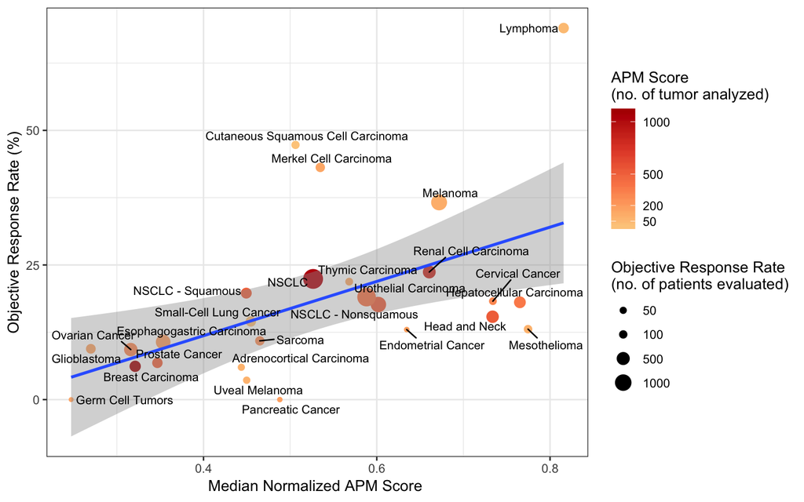

```r
ggplot(sm_data, aes(x=Pool_APM, y=Pool_ORR)) +
    geom_point(aes(color=Patients_APM, size=Patients_ORR)) +
    geom_smooth(method="lm", se=T)  +
    geom_text_repel(aes(label=Cancer_Type), size=3)  +
    labs(x="Median Normalized APM Score ", y="Objective Response Rate (%)",
         size="Objective Response Rate\n(no. of patients evaluated)",
         color = "APM Score\n(no. of tumor analyzed)") +
    scale_size_continuous(breaks = c(50, 100, 500, 1000)) +
    scale_color_gradientn(colours = RColorBrewer::brewer.pal(5, name="OrRd")[-1],
                          breaks = c(50, 200, 500, 1000)) +
    theme_bw()
```

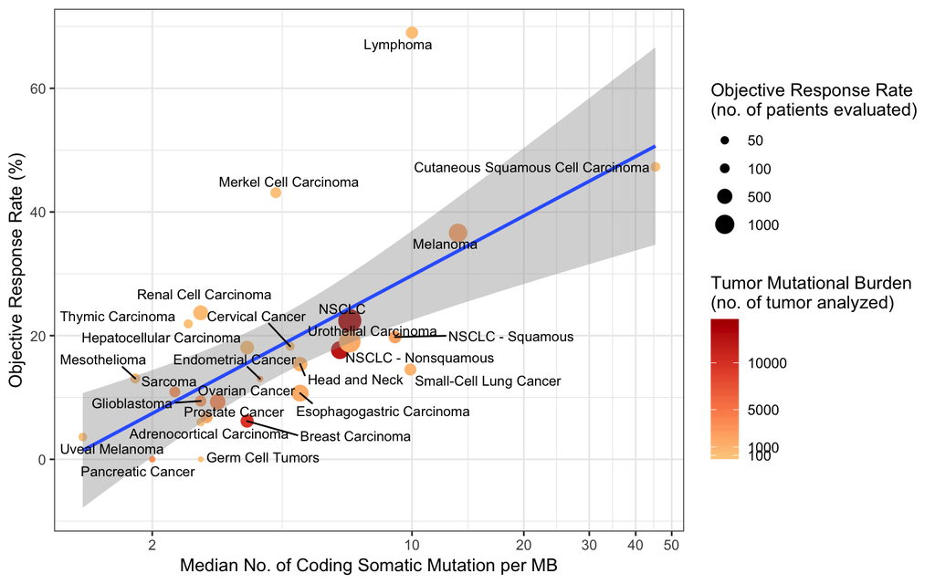

```r
ggplot(sm_data, aes(x=Pool_TMB, y=Pool_ORR)) +
    geom_point(aes(color=Patients_TMB, size=Patients_ORR)) +
    geom_smooth(method="lm", se=T)  +
    geom_text_repel(aes(label=Cancer_Type), size=3)  +
    labs(x="Median No. of Coding Somatic Mutation per MB", y="Objective Response Rate (%)",
         color = "Tumor Mutational Burden\n(no. of tumor analyzed)",
         size="Objective Response Rate\n(no. of patients evaluated)") +
    scale_x_continuous(trans = log_trans(),
                       breaks = c(2, 10, 20, 30, 40, 50),
                       labels = c(2, 10, 20, 30, 40, 50)) +
    scale_size_continuous(breaks = c(50, 100, 500, 1000)) +
    scale_color_gradientn(colours = RColorBrewer::brewer.pal(5, name="OrRd")[-1],
                          breaks = c(100, 1000, 5000, 10000)) +
    theme_bw()
```

### TIGS definition and performance

From the aspect of biological process, TMB release is independent from processing and presentation of tumor antigens. Now that we have found TMB and APM are biomarkers which can predict object reponse rate of cancer type in immunotherapy, these two factors are independent, and are both required for tumor immunogenicity determination, **why not integrate them as a new biomarker which should be better than TMB?**

Therefore, theoretically, tumor immunogenicity can be represented as

$$[“Tumor \quad antigenicity”] \times [“Antigen \quad processing \quad and \quad presenting \quad status”].$$

We use `log(TMB)` here because `log(TMB)` has been proved to have a linear relationship with ORR. So the formula can be written as

$$TIGS = APS_{normalized} \times log(TMB)$$

However, some tumors have TMB level below 1 mutation/ Mb, to avoid minus number in quantifying “tumor antigenicity”, we add number 1 to all normalized TMB. So in this case, the TIGS formula is

$$TIGS = APS_{normalized} \times log(TMB + 1)$$

> When TMB < 1 mutation/Mb, the `log(TMB)` would less than 0, if APS is very big, we would get a big minus number in this case, which against common sense.

Now we construct a linear model by integrate TMB and APM.

```r
lm(Pool_ORR ~ log(Pool_TMB +1):Pool_APM, data = sm_data)  -> fit3

summary(fit3)
```

```
#>
#> Call:
#> lm(formula = Pool_ORR ~ log(Pool_TMB + 1):Pool_APM, data = sm_data)
#>
#> Residuals:
#>      Min       1Q   Median       3Q      Max
#> -13.3507  -6.8209  -0.9202   2.3742  25.7436
#>
#> Coefficients:
#>                            Estimate Std. Error t value Pr(>|t|)
#> (Intercept)                  -6.601      4.050  -1.630    0.116
#> log(Pool_TMB + 1):Pool_APM   26.885      3.911   6.875 4.13e-07 ***
#> ---
#> Signif. codes:  0 '***' 0.001 '**' 0.01 '*' 0.05 '.' 0.1 ' ' 1
#>
#> Residual standard error: 9.245 on 24 degrees of freedom
#> Multiple R-squared:  0.6632, Adjusted R-squared:  0.6492
#> F-statistic: 47.27 on 1 and 24 DF,  p-value: 4.134e-07
```

We observe that 66% variance of ORR can be explained by TIGS, this result is indeed bettern than TMB.

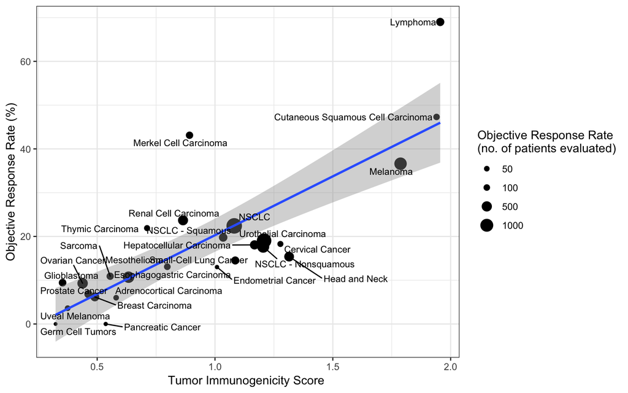

```r
sm_data$tigs = sm_data$Pool_APM * log(sm_data$Pool_TMB + 1)

ggplot(sm_data, aes(x=tigs, y=Pool_ORR)) +
    geom_point(aes(size=Patients_ORR)) +
    geom_smooth(method="lm", se=T)  +
    geom_text_repel(aes(label=Cancer_Type), size=3)  +
    labs(x="Tumor Immunogenicity Score ", y="Objective Response Rate (%)",
         size="Objective Response Rate\n(no. of patients evaluated)") +
    scale_size_continuous(breaks = c(50, 100, 500, 1000)) +
    theme_bw()
```

### More exploration of TIGS formula

**Would other combination of TMB and APS be better?**

As mentioned above, we constructed the formula of `TIGS` according to our understanding of “tumor antigenicity”. Is there a better combination of these two factors?

There are three basic models we take into consideration.

- Model 1: $ORR = d \times (a \times APS + b\times log(TMB)) + c$, i.e. $TIGS = a \times APS + b \times log(TMB)$
- Model 2: $ORR = a \times (APS \times log(TMB)) + b$, i.e. $TIGS = APS \times log(TMB)$ (This is the model we used above)
- Model 3: $ORR = e \times (a \times APS + b\times log(TMB) + c\times APS \times log(TMB)) + d$, i.e. $TIGS = a \times APS + b\times log(TMB) + c\times APS \times log(TMB)$

a, b, c, d and e here are coefficients. In R, we don’t need to write them in models, it will take care of them.

Now, let’s observe the results.

```r
# Model 1
lm(Pool_ORR ~ log(Pool_TMB)+Pool_APM, data = sm_data)  %>% summary()
```

```
#>
#> Call:
#> lm(formula = Pool_ORR ~ log(Pool_TMB) + Pool_APM, data = sm_data)
#>
#> Residuals:
#>     Min      1Q  Median      3Q     Max
#> -12.628  -7.138  -1.461   3.109  29.314
#>
#> Coefficients:
#>               Estimate Std. Error t value Pr(>|t|)
#> (Intercept)    -20.490      7.375  -2.778 0.010686 *
#> log(Pool_TMB)   12.172      2.761   4.409 0.000203 ***
#> Pool_APM        39.417     12.643   3.118 0.004840 **
#> ---
#> Signif. codes:  0 '***' 0.001 '**' 0.01 '*' 0.05 '.' 0.1 ' ' 1
#>
#> Residual standard error: 10.16 on 23 degrees of freedom
#> Multiple R-squared:  0.6101, Adjusted R-squared:  0.5762
#> F-statistic: 17.99 on 2 and 23 DF,  p-value: 1.979e-05
```

```r
# Model 2
lm(Pool_ORR ~ log(Pool_TMB):Pool_APM, data = sm_data)  %>% summary()
```

```
#>
#> Call:
#> lm(formula = Pool_ORR ~ log(Pool_TMB):Pool_APM, data = sm_data)
#>
#> Residuals:
#>     Min      1Q  Median      3Q     Max
#> -12.382  -6.262  -2.004   2.911  25.404
#>
#> Coefficients:
#>                        Estimate Std. Error t value Pr(>|t|)
#> (Intercept)              -1.857      3.496  -0.531      0.6
#> log(Pool_TMB):Pool_APM   25.092      3.707   6.769 5.31e-07 ***
#> ---
#> Signif. codes:  0 '***' 0.001 '**' 0.01 '*' 0.05 '.' 0.1 ' ' 1
#>
#> Residual standard error: 9.34 on 24 degrees of freedom
#> Multiple R-squared:  0.6563, Adjusted R-squared:  0.642
#> F-statistic: 45.83 on 1 and 24 DF,  p-value: 5.306e-07
```

```r
# Model 3
lm(Pool_ORR ~ log(Pool_TMB)*Pool_APM, data = sm_data)  %>% summary()
```

```
#>
#> Call:
#> lm(formula = Pool_ORR ~ log(Pool_TMB) * Pool_APM, data = sm_data)
#>
#> Residuals:
#>      Min       1Q   Median       3Q      Max
#> -14.0233  -6.8783  -0.4445   3.4839  25.8232
#>
#> Coefficients:
#>                        Estimate Std. Error t value Pr(>|t|)
#> (Intercept)               12.24      16.85   0.726   0.4753
#> log(Pool_TMB)            -12.93      12.08  -1.071   0.2959
#> Pool_APM                 -23.41      31.80  -0.736   0.4693
#> log(Pool_TMB):Pool_APM    46.72      21.96   2.127   0.0449 *
#> ---
#> Signif. codes:  0 '***' 0.001 '**' 0.01 '*' 0.05 '.' 0.1 ' ' 1
#>
#> Residual standard error: 9.463 on 22 degrees of freedom
#> Multiple R-squared:  0.6766, Adjusted R-squared:  0.6325
#> F-statistic: 15.34 on 3 and 22 DF,  p-value: 1.314e-05
```

The model 1 is the worst one. Model 3 is a little better than model 2, however model 2 is much simpler (model 2 is included in model 3!). Following **Occam’s razor**, we choose model 2 when compare it with model 3. We also choose model 2 when compare it with model 1 because it is better and consist with the fact APM and TMB are relatively independent but not absolutely independent. To summary, model 2 is the best option.

**Any promotion of formula $TIGS = APS \times log(TMB + 1)$?**

We still have a question about TIGS formula. The TMB in formula is calculated as

$$TMB = ln(\frac{whole \quad exome \quad mutation \quad number}{38} + 1 )$$

> We choose nonsynonymous mutations because they have functional effects. Only functional effects on protein will generate neo-antigen (peptide).

We use 38 here because 38 MB is the estimated length of exome, so we can normalize TMB to per MB. However, in math model, there may be a better value “a” than 38. We don’t know yet, so we need to explore this “a” value.

We simulate “a” value from 0.1 to 10000 with step size 0.1 in the following formula, the resulted TIGS is then used to fit a linear model for pan-cancer ICI ORR prediction. We calculate differnt R Square value under each “a” and see how it changes.

$$TIGS = APS_{normalized} \times ln(\frac{whole \quad exome \quad mutation \quad number}{a} + 1)$$

Implementation:

```r
df = sm_data
df$APS = df$Pool_APM
df$TMB = df$Pool_TMB * 38 # transform back to whole exome nonsynonymous mutation number
df$ORR = df$Pool_ORR

df = dplyr::select(df, APS, TMB, ORR)


calcTrends = function(df, a){
    sapply(a, function(x, data){
        summary(lm(ORR ~ APS : log((TMB/x + 1)), data = df) )$r.squared
    }, data = df)
}
```

```r
a = seq(0.1,10000,0.1)
res = calcTrends(df, a)

res_df = data.frame(a = a, Rsquare = res)
```

Plot the simulation result.

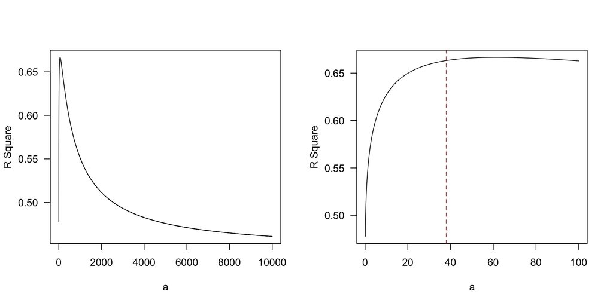

```r
opar = par(no.readonly = TRUE)
par(mfrow=c(1,2))
plot(res_df, las = 1, xlab = "a", ylab = "R Square", type = "l")
plot(res_df[1:1000,], las = 1, xlab = "a", ylab = "R Square", type = "l")
abline(v = 38, lty = 2, col = "red")
```

```r
par(opar)
```

## Performance comparison on immunotherapy clinical response prediction and survival benefit

Description of datasets please see preprocessing part or “Method Section” of manuscript.

TMB is a well-known biomarker and has been applied. Considering our TIGS is based on TMB, thus the most important point we wanna do in this section is comparing the prediction/clinical perfermance between TMB and TIGS.

However, some other biomarkers can predict immunotherapy response have been studied by other groups. Therefore, this section we will include following biomarkers in comparsion.

- APS - antigen processing and presenting efficiency score
- TMB - tumor mutation burden
- TIGS - tumor immunogenicity score
- IIS - immune infiltration score
- [IFNG](https://www.jci.org/articles/view/91190#SEC4) - interferon gamma response biomarkers of 6 genes including *IFNG, STAT1, IDO1, CXCL10, CXCL9*, and *HLA-DRA*
- CD8 - gene expression level of CD8A + CD8B
- PDL1 - an immunohistochemistry (IHC) biomarker approved by FDA. This study we use *PD-L1* gene expression as the IHC surrogate
- [TIDE](https://www.nature.com/articles/s41591-018-0136-1) - TIDE signature which integrates the expression signatures of T cell dysfunction and T cell exclusion to model tumor immune evasion.

The predicted values of gene expression biomarkers (i.e. IFNG, CD8, PDL1) are the average values among all members defined by the original publications.

### Preprocessing of immunotherapy datasets

The first step is to preprocess 3 immunotherapy datasets with gene expression, TMB and clinical outcome available. APS from Pancan analysis is used to normalize APS here.

```r
# get min and max APM value based on TCGA and GEO pan-cancer data
load("results/df_all.RData")
min_APS = min(df_all$APM)
max_APS = max(df_all$APM)
rm(df_all)

# load gene list
load("results/merged_geneList.RData")
# load function
source("../code/functions.R")
```

#### Hugo et al 2016 dataset

```r
## Data source: Genomic and Transcriptomic Features of Response to Anti-PD-1 Therapy in Metastatic Melanoma. Cell 2016 Mar 24;165(1):35-44. PMID: 26997480
suppressPackageStartupMessages(library(GEOquery))
library(readxl)
geo_dir = "../data/GEOdata"

gse = "GSE78220"
GSE_78220 = getGEO(gse, GSEMatrix = TRUE, AnnotGPL = TRUE, destdir = geo_dir)
GSE_78220 = GSE_78220$GSE78220_series_matrix.txt.gz

#### Download gene expression using following command
# download.file(url = "https://www.ncbi.nlm.nih.gov/geo/download/?acc=GSE78220&format=file&file=GSE78220%5FPatientFPKM%2Exlsx", destfile = "../data/GSE78220_FPKM.xlsx")

GSE78220_FPKM = readxl::read_xlsx("../data/GSE78220_FPKM.xlsx")

GSE78220_FPKM = GSE78220_FPKM %>%
    as.data.frame() %>%
    mutate(mean_expr = rowMeans(.[, -1], na.rm = TRUE)) %>%
    arrange(Gene, desc(mean_expr)) %>%
    distinct(Gene, .keep_all = TRUE) %>%
    dplyr::select(-mean_expr) %>%
    as.tibble()

# pData(GSE_78220) %>% View()

# normalize gene expression as log(x + 1)
GSE78220_Norm = GSE78220_FPKM
GSE78220_Norm[,-1] = log2(GSE78220_Norm[,-1] + 1)

# apply gsva
applyGSVA(merged_geneList, group_col = "Cell_type",
          gene_col = "Symbol", ExprMatList = list(GSE78220_Norm), method = "gsva") -> gsva.hugo2016

gsva.hugo2016 = calc_TisIIs(gsva.hugo2016[[1]])

# normalize APS
APS_hugo = gsva.hugo2016$APM
APS_hugo = (APS_hugo - min_APS) / (max_APS - min_APS)

names(APS_hugo) = colnames(GSE78220_Norm)[-1]
APS_hugo
names(APS_hugo) = sub(pattern = "(Pt.*)\\.baseline", "\\1", names(APS_hugo))


# keep biggest value
APS_hugo = APS_hugo[-21]
names(APS_hugo)[c(14, 20)] = c("Pt16", "Pt27")
APS_hugo

# keep corresponding expression data for downstream analysis
rna_hugo = GSE78220_Norm[, -22]
colnames(rna_hugo)[-1] = names(APS_hugo)
save(rna_hugo, file = "results/Hugo2016_RNA.RData")


GSE78220.APS = tibble(PatientID = names(APS_hugo), APS=APS_hugo, IIS = gsva.hugo2016$IIS[-21])

# read clincal and tmb data
GSE_78220.TMB = read_csv("../data/Cell2016.csv", col_types = cols())
GSE_78220.TMB$nTMB = GSE_78220.TMB$TotalNonSyn / 38

info_hugo = full_join(GSE_78220.TMB, GSE78220.APS, by = "PatientID")
info_hugo = info_hugo[,c(1:5, 14:16, 13)]

# calculate TIGS score
info_hugo$TIGS = log(info_hugo$nTMB) * info_hugo$APS

save(info_hugo, file = "results/Hugo2016_Info.RData")
```

#### Van Allen et al 2015 dataset

```r
#----------------------------------------------------------
# Data source :
# Science 2015: Genomic correlates of response to CTLA4 blockade in metastatic melanoma
#--------------------------
library(readxl)
suppressPackageStartupMessages(library(tidyverse))
science2015_TMB = read_xlsx("../data/Science2015_TMB_List_AllPatients.xlsx")
science2015_cli1 = read_xlsx("../data/Science2015_Clinical.xlsx", sheet = 1)
science2015_cli2 = read_xlsx("../data/Science2015_Clinical.xlsx", sheet = 2)
science2015_rna = read_tsv("../data/MEL-IPI-Share.rpkm.gct", col_types = cols())

#---- Preprocess
vc.nonSilent = c("Frame_Shift_Del", "Frame_Shift_Ins", "Splice_Site", "Translation_Start_Site",
                 "Nonsense_Mutation", "Nonstop_Mutation", "In_Frame_Del",
                 "In_Frame_Ins", "Missense_Mutation")

science2015_TMB %>% group_by(patient) %>%
    summarise(TotalMutation=n(),
              TotalNonSyn=sum(Variant_Classification %in% vc.nonSilent),
             nTMB = TotalNonSyn / 38) -> science2015_TMB_summary

#---- remove duplicate symbols of rna data
science2015_rna %>% mutate(symbol = sub("(.*)\\..*$", "\\1", Description)) %>%
    dplyr::select(-Name, -Description) %>%
    dplyr::select(symbol, everything()) %>%
    as.data.frame() %>%
    mutate(mean_expr = rowMeans(.[, -1], na.rm = TRUE)) %>%
    arrange(symbol, desc(mean_expr)) %>%
    distinct(symbol, .keep_all = TRUE) %>%
    dplyr::select(-mean_expr) %>%
    as.tibble() -> science2015_ge

length(intersect(science2015_ge$symbol, GSE78220_Norm$Gene))
# the gene number of science paper is bigger than hugo 2016
# maybe miRNA and some other RNA included
# keep them almost equal\
science2015_ge = science2015_ge %>%
    filter(symbol %in% GSE78220_Norm$Gene)

science2015_ge[, -1] = log2(science2015_ge[, -1] + 1)

applyGSVA(merged_geneList, group_col = "Cell_type",
          gene_col = "Symbol",
          ExprMatList = list(science2015_ge), method = "gsva") -> gsva.VanAllen2015

gsva.VanAllen2015 = calc_TisIIs(gsva.VanAllen2015[[1]])

APS_VanAllen = gsva.VanAllen2015$APM
names(APS_VanAllen) = colnames(science2015_ge)[-1]
APS_VanAllen = (APS_VanAllen - min_APS) / (max_APS - min_APS)

APS_VanAllen
names(APS_VanAllen) = sub("^MEL.IPI_(.*)\\.Tumor.*$", "\\1", names(APS_VanAllen))
APS_VanAllen

rna_VanAllen = science2015_ge
colnames(rna_VanAllen)[-1] = names(APS_VanAllen)
## save gene experssion
save(rna_VanAllen, file = "results/VanAllen2015_RNA.RData")

APS_VanAllen_df = tibble(patient = names(APS_VanAllen), APS = APS_VanAllen,
                         IIS = gsva.VanAllen2015$IIS)

science2015_cli = bind_rows(
    dplyr::select(science2015_cli1, patient, age_start, RECIST, overall_survival, progression_free, primary, group,
           histology, stage, gender, dead, progression, neos50),
    dplyr::select(science2015_cli2, patient, age_start, RECIST, overall_survival, progression_free, primary,
           group, histology, stage, gender, dead, progression) %>% filter(patient %in% c("Pat20", "Pat91"))
)
# combine three datasets
info_VanAllen = full_join(full_join(science2015_cli, APS_VanAllen_df, by = "patient"),
                         science2015_TMB_summary, by="patient")

info_VanAllen$TIGS = info_VanAllen$APS * log(info_VanAllen$nTMB +1) # to avoid TIGS <0, TIGS = log(TMB +1) *APM for this dataset

save(info_VanAllen, file = "results/VanAllen2015_Info.RData")
```

#### Snyder et al 2017 dataset

```r
#----------------------------------------------------------------
# Contribution of systemic and somatic factors to clinical response and resistance in urothelial cancer: an exploratory multi-omic analysis
#---------------------------------------------------------------
# Data Source: https://github.com/XSLiuLab/multi-omic-urothelial-anti-pdl1
# This is a fork repository, original link can also be found in this link

library(tidyverse)
uro_cli = read_csv("../data/data_clinical.csv", col_types = cols())
uro_counts = read_csv("../data/data_counts.csv", col_types = cols())
uro_variants = read_csv("../data/data_variants.csv",
                        col_types = "c??????")
uro_rna = read_csv("../data/data_kallisto.csv", col_types = cols())
uro_rna_wide = reshape2::dcast(uro_rna, gene_name ~ patient_id, value.var = "est_counts")

# try remove duplicated genes
uro_rna_wide %>%
    as.data.frame() %>%
    mutate(mean_expr = rowMeans(.[, -1], na.rm = TRUE)) %>%
    arrange(gene_name, desc(mean_expr)) %>%
    distinct(gene_name, .keep_all = TRUE) %>%
    dplyr::select(-mean_expr) %>%
    as.tibble() -> uro_rna_ge

length(intersect(uro_rna_ge$gene_name, GSE78220_FPKM$Gene))
uro_rna_ge = dplyr::filter(uro_rna_ge, gene_name %in% GSE78220_FPKM$Gene)
uro_rna_ge_Norm = uro_rna_ge
uro_rna_ge_Norm[, -1] = log2(uro_rna_ge_Norm[,-1]+1)

## apply GSVA
applyGSVA(merged_geneList, group_col = "Cell_type",
          gene_col = "Symbol", ExprMatList = list(uro_rna_ge_Norm), method = "gsva") -> gsva.Snyder

gsva.Snyder = calc_TisIIs(gsva.Snyder[[1]])

APS_Snyder = gsva.Snyder$APM
APS_Snyder = (APS_Snyder - min_APS) / (max_APS - min_APS)

## save gene expression
rna_Snyder = uro_rna_ge_Norm
save(rna_Snyder, file = "results/Snyder2017_RNA.RData")

APS_Snyder_df = tibble(patient_id = colnames(uro_rna_ge_Norm)[-1],
                       APS = APS_Snyder,
                       IIS = gsva.Snyder$IIS)

uro_cli_2 = uro_cli %>%
    dplyr::select(patient_id, Age, Sex, is_benefit, is_benefit_os, os, `Alive Status`) %>%
    mutate(event = ifelse(`Alive Status` == 'Y', 0, 1))

uro_tmb = uro_variants %>%
    group_by(patient_id) %>%
    summarise(TMB = n(), Nonsyn = sum(!is.na(gene_name)), nTMB = TMB/38) %>%
    mutate(patient_id = as.character(patient_id))

info_Snyder = dplyr::full_join(uro_cli_2, dplyr::full_join(uro_tmb, APS_Snyder_df))
info_Snyder$TIGS = info_Snyder$APS * log(info_Snyder$nTMB)

save(info_Snyder, file = "results/Snyder2017_Info.RData")

rm(list = ls())
```

### Gene expression biomarkers for response to immune checkpoint blockade

This section we will describe how to calculate predicted value of gene signature biomarker using gene expression data.

Load data firstly.

```r
# library(tidyverse)
sigList = read_csv("../data/ICBbiomarkerSignature.csv", comment = "#", col_types = cols())
load("results/Hugo2016_RNA.RData")
load("results/VanAllen2015_RNA.RData")
load("results/Snyder2017_RNA.RData")
```

Check if all gene signatures are in data.

```r
all(sigList$Genes %in% rna_hugo$Gene)
```

```
#> [1] TRUE
```

```r
all(sigList$Genes %in% rna_Snyder$gene_name)
```

```
#> [1] TRUE
```

```r
all(sigList$Genes %in% rna_VanAllen$symbol)
```

```
#> [1] TRUE
```

We got all `TRUE`. Next we retrieve all gene expression values and then calculate average.

```r
rna_hugo_df = rna_hugo %>%
    dplyr::filter(Gene %in% sigList$Genes)

rna_VanAllen_df = rna_VanAllen %>%
    dplyr::filter(symbol %in% sigList$Genes) %>%
    rename(Gene = symbol)

rna_Snyder_df = rna_Snyder %>%
    dplyr::filter(gene_name %in% sigList$Genes) %>%
    rename(Gene = gene_name)
```

Combine them with `sigList`, then transform these `data.frame` to long format, calculate mean gene expression and transform back to wide format.

```r
rna_hugo_sigExpr = rna_hugo_df %>%
    dplyr::right_join(sigList, by=c("Gene"="Genes")) %>%
    tidyr::gather(key = "sample", value = "expression", -Gene, -Signature) %>%
    dplyr::group_by(sample, Signature) %>%
    dplyr::summarise(expression = mean(expression)) %>%
    tidyr::spread(key=Signature, value=expression) %>%
    dplyr::mutate(study = "Hugo2016")

rna_VanAllen_sigExpr = rna_VanAllen_df %>%
    dplyr::right_join(sigList, by=c("Gene"="Genes")) %>%
    tidyr::gather(key = "sample", value = "expression", -Gene, -Signature) %>%
    dplyr::group_by(sample, Signature) %>%
    dplyr::summarise(expression = mean(expression)) %>%
    tidyr::spread(key=Signature, value=expression) %>%
    dplyr::mutate(study = "VanAllen2015")

rna_Snyder_sigExpr = rna_Snyder_df %>%
    dplyr::right_join(sigList, by=c("Gene"="Genes")) %>%
    tidyr::gather(key = "sample", value = "expression", -Gene, -Signature) %>%
    dplyr::group_by(sample, Signature) %>%
    dplyr::summarise(expression = mean(expression)) %>%
    tidyr::spread(key=Signature, value=expression) %>%
    dplyr::mutate(study = "Snyder2017")
```

Show results as tables.

```r
DT::datatable(rna_hugo_sigExpr,
              options = list(scrollX = TRUE, keys = TRUE), rownames = FALSE,
              caption = "gene signature expression in Hugo 2016 dataset")
```

| sample | CD8 | IFNG | PDL1 | study |
| --- | --- | --- | --- | --- |
| Pt1 | 2.91307120903569 | 4.46470188553746 | 1.52683754324352 | Hugo2016 |
| Pt10 | 0.507762941682716 | 1.58563930278468 | 0.180653288881013 | Hugo2016 |
| Pt12 | 0.346843030041706 | 1.75827541629422 | 0.482903512197136 | Hugo2016 |
| Pt13 | 3.97971907560311 | 5.40530909528476 | 1.97797225097424 | Hugo2016 |
| Pt14 | 1.5918864326849 | 3.89041595867306 | 4.38906425888949 | Hugo2016 |
| Pt15 | 3.17042429044613 | 3.99212261403239 | 0.819427850537845 | Hugo2016 |
| Pt16 | 1.49220649386557 | 2.77941912433215 | 1.4577098499113 | Hugo2016 |
| Pt19 | 3.11344246009358 | 3.39210642139884 | 1.16610160670691 | Hugo2016 |
| Pt2 | 3.15371395243211 | 5.0906056915083 | 2.39027421964636 | Hugo2016 |
| Pt20 | 6.37881844761244 | 6.53553933506539 | 2.93558421024385 | Hugo2016 |

[output cut: 17 more lines]

```r
DT::datatable(rna_VanAllen_sigExpr,
              options = list(scrollX = TRUE, keys = TRUE), rownames = FALSE,
              caption = "gene signature expression in VanAllen 2015 dataset")
```

| sample | CD8 | IFNG | PDL1 | study |
| --- | --- | --- | --- | --- |
| Pat02 | 2.04436232982035 | 2.73450071117125 | 0.608050097638462 | VanAllen2015 |
| Pat03 | 0.649293755442578 | 2.69406580747067 | 0.436057524315705 | VanAllen2015 |
| Pat04 | 1.89430545685639 | 3.86174044852478 | 1.14155680270974 | VanAllen2015 |
| Pat06 | 2.78116292373613 | 4.76328583555838 | 1.96780628557711 | VanAllen2015 |
| Pat08 | 1.95108444584953 | 5.09644939456963 | 1.45220070056743 | VanAllen2015 |
| Pat118 | 2.3096351282643 | 4.72405338859576 | 1.1029634889793 | VanAllen2015 |
| Pat119 | 1.25722806896377 | 3.81660214819775 | 0.82059356061745 | VanAllen2015 |
| Pat123 | 1.1806356087155 | 3.54790000710972 | 0.773209447834687 | VanAllen2015 |
| Pat126 | 1.46085857172156 | 4.44427307008674 | 1.00262765030154 | VanAllen2015 |
| Pat14 | 1.31906143157252 | 3.17990513350778 | 1.05341411018827 | VanAllen2015 |

[output cut: 32 more lines]

```r
DT::datatable(rna_Snyder_sigExpr,
              options = list(scrollX = TRUE, keys = TRUE), rownames = FALSE,
              caption = "gene signature expression in Snyder 2017 dataset")
```

| sample | CD8 | IFNG | PDL1 | study |
| --- | --- | --- | --- | --- |
| 0040 | 6.26934033132172 | 6.24746671897737 | 6.22881888285521 | Snyder2017 |
| 0471 | 6.53524046523003 | 6.29206969640024 | 5.83288849553758 | Snyder2017 |
| 0522 | 8.28345707841814 | 10.608885068383 | 8.48381738921312 | Snyder2017 |
| 1233 | 8.37505731036604 | 9.30267643504613 | 6.10852445677817 | Snyder2017 |
| 1249 | 4.05427383258194 | 7.67242826997204 | 9.50977607298953 | Snyder2017 |
| 1849 | 8.92979881707126 | 7.56346656070013 | 7.02236759107535 | Snyder2017 |
| 1994 | 7.29208241287616 | 8.93853498301082 | 7.84548942368553 | Snyder2017 |
| 2131 | 8.86427722494719 | 10.5919897417012 | 9.93221416130499 | Snyder2017 |
| 2278 | 6.55390173423794 | 8.10050970609488 | 7.62205181945638 | Snyder2017 |
| 2389 | 8.68099891513542 | 9.82534481279003 | 7.25738746551743 | Snyder2017 |

[output cut: 15 more lines]

Lastly, merge the three result datasets for downstream analysis.

```r
GEBiomarker = dplyr::bind_rows(rna_hugo_sigExpr, rna_VanAllen_sigExpr, rna_Snyder_sigExpr)

if (!file.exists("results/GEBiomarker.RData")){
    save(GEBiomarker, file = "results/GEBiomarker.RData")
}
```

### Input file generation for TIDE

TIDE is developed by Shirley Liu lab, software website is available at (http://tide.dfci.harvard.edu/). We can generate input file for TIDE and submit it to the website for TIDE score calculation.

Following suggestions provided at TIDE website, we firstly generate input files for three immunotherapy datasets .

```r
rna_Snyder = rna_Snyder %>%
  rename(Gene = gene_name)

rna_VanAllen = rna_VanAllen %>%
  rename(Gene = symbol)

# normalized expression substract mean expression
generateInput = function(df) {
  df %>%
    mutate(Ref = rowMeans(.[, -1])) %>%
    mutate_at(vars(-Gene, -Ref), `-`, quote(Ref)) %>%  #f <- function(num, ref) num - !!ref
    select(-Ref) %>%
    column_to_rownames(var = "Gene") %>%
    as.data.frame()
}

TIDE_hugo = generateInput(rna_hugo)
TIDE_VanAllen = generateInput(rna_VanAllen)
TIDE_Snyder = generateInput(rna_Snyder)
if (!file.exists("results/TIDE_input_hugo.tsv")){
  write.table(TIDE_hugo, file="results/TIDE_input_hugo.tsv", quote = FALSE, sep = "\t", row.names = TRUE, col.names = TRUE)
  write.table(TIDE_VanAllen, file="results/TIDE_input_VanAllen.tsv", quote = FALSE, sep = "\t", row.names = TRUE, col.names = TRUE)
  write.table(TIDE_Snyder, file="results/TIDE_input_Snyder.tsv", quote = FALSE, sep = "\t", row.names = TRUE, col.names = TRUE)
}

rm(list = ls())
```

Next we submit the three `tsv` file to TIDE website. Previous immunotherapy item is set as “No”. The result `csv` files are saved to `report/results` directory.

### ROC comparison

This section we compare ROC (AUC value) of biomarkers for response prediction.

```r
library(pROC)
```

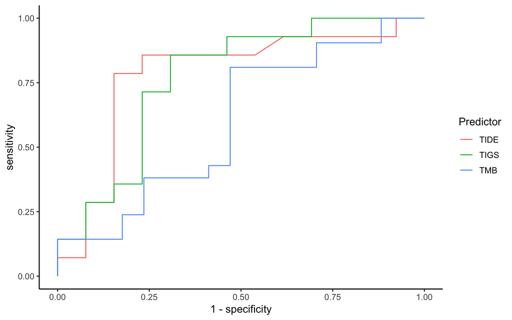

```r
library(tidyverse)
#theme_set(theme_bw())
#library(cowplot)

#------------------------------------------
# Load data
load("results/Hugo2016_Info.RData")
load("results/VanAllen2015_Info.RData")
load("results/Snyder2017_Info.RData")

load("results/GEBiomarker.RData")

# Of note, output csv from TIDE website has extra "" in last line
#          please remove it before load data
TIDE_hugo = read_csv("results/TIDE_output_hugo.csv", col_types = cols())
TIDE_Snyder = read_csv("results/TIDE_output_Snyder.csv", col_types = cols())
TIDE_VanAllen = read_csv("results/TIDE_output_VanAllen.csv", col_types = cols())

#-----------------------------------------
# Merge datasets
info_hugo = info_hugo %>%
  dplyr::left_join(dplyr::filter(GEBiomarker, study=="Hugo2016") %>%
                      dplyr::select(-study), by=c("PatientID" = "sample")) %>%
  dplyr::left_join(TIDE_hugo %>% dplyr::select(Patient, TIDE), by = c("PatientID" = "Patient"))

#------------------------------------------
# Hugo 2016
hugo2016_roc_TMB = roc(info_hugo$Response, info_hugo$nTMB)
hugo2016_roc_APS = roc(info_hugo$Response, info_hugo$APS)
hugo2016_roc_TIGS = roc(info_hugo$Response, info_hugo$TIGS)
hugo2016_roc_IIS = roc(info_hugo$Response, info_hugo$IIS)
hugo2016_roc_CD8 = roc(info_hugo$Response, info_hugo$CD8)
hugo2016_roc_IFNG = roc(info_hugo$Response, info_hugo$IFNG)
hugo2016_roc_PDL1 = roc(info_hugo$Response, info_hugo$PDL1)
hugo2016_roc_TIDE = roc(info_hugo$Response, info_hugo$TIDE)

ggroc(list(TMB=hugo2016_roc_TMB, TIGS=hugo2016_roc_TIGS, TIDE=hugo2016_roc_TIDE), legacy.axes = TRUE) +
    labs(color = "Predictor") + ggpubr::theme_classic2(base_size = 12, base_family = "Arial")
```

```r
# AUC of predictors
auc(hugo2016_roc_TMB)   # AUC of TMB
```

```
#> Area under the curve: 0.5994
```

```r
auc(hugo2016_roc_APS)   # AUC of APS
```

```
#> Area under the curve: 0.6978
```

```r
auc(hugo2016_roc_TIGS)  # AUC of TIGS
```

```
#> Area under the curve: 0.7692
```

```r
auc(hugo2016_roc_IIS)   # AUC of IIS
```

```
#> Area under the curve: 0.6154
```

```r
auc(hugo2016_roc_CD8)   # AUC of CD8
```

```
#> Area under the curve: 0.5055
```

```r
auc(hugo2016_roc_IFNG)  # AUC of IFNG
```

```
#> Area under the curve: 0.4945
```

```r
auc(hugo2016_roc_PDL1)  # AUC of PDL1
```

```
#> Area under the curve: 0.4286
```

```r
auc(hugo2016_roc_TIDE)  # AUC of TIDE
```

```
#> Area under the curve: 0.783
```

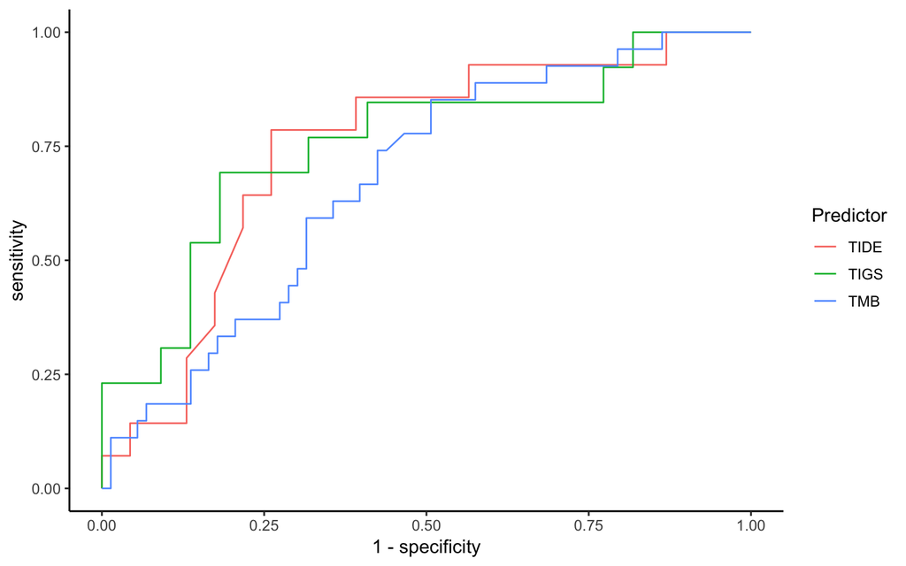

```r
#---------------------------
# VanAllen 2015

info_VanAllen = info_VanAllen %>%
  dplyr::left_join(dplyr::filter(GEBiomarker, study=="VanAllen2015") %>%
                      dplyr::select(-study), by=c("patient" = "sample")) %>%
  dplyr::left_join(TIDE_VanAllen %>% dplyr::select(Patient, TIDE), by = c("patient" = "Patient"))

info_VanAllen2 = info_VanAllen %>%
    mutate(Response = case_when(
        group == "response" ~ "R",
        group == "nonresponse" ~"NR",
        TRUE ~ NA_character_
    )) %>% filter(!is.na(Response))


## -- using following command if only compare patients with TIGS availble
## -- the result are basically same
# info_VanAllen2 = info_VanAllen %>%
#     mutate(Response = case_when(
#         group == "response" ~ "R",
#         group == "nonresponse" ~"NR",
#         TRUE ~ NA_character_
#     )) %>% filter(!is.na(Response), !is.na(TIGS))


VanAllen2015_roc_TMB = roc(info_VanAllen2$Response, info_VanAllen2$nTMB)
VanAllen2015_roc_APS = roc(info_VanAllen2$Response, info_VanAllen2$APS)
VanAllen2015_roc_TIGS = roc(info_VanAllen2$Response, info_VanAllen2$TIGS)
VanAllen2015_roc_IIS = roc(info_VanAllen2$Response, info_VanAllen2$IIS)
VanAllen2015_roc_CD8 = roc(info_VanAllen2$Response, info_VanAllen2$CD8)
VanAllen2015_roc_IFNG = roc(info_VanAllen2$Response, info_VanAllen2$IFNG)
VanAllen2015_roc_PDL1 = roc(info_VanAllen2$Response, info_VanAllen2$PDL1)
VanAllen2015_roc_TIDE = roc(info_VanAllen2$Response, info_VanAllen2$TIDE)

ggroc(list(TMB=VanAllen2015_roc_TMB,TIGS=VanAllen2015_roc_TIGS, TIDE=VanAllen2015_roc_TIDE),
      legacy.axes = TRUE) +
    labs(color = "Predictor") +
    ggpubr::theme_classic2(base_size = 12, base_family = "Arial")
```

```r
# AUC of predictors
auc(VanAllen2015_roc_TMB)   # AUC of TMB
```

```
#> Area under the curve: 0.6748
```

```r
auc(VanAllen2015_roc_APS)   # AUC of APS
```

```
#> Area under the curve: 0.6894
```

```r
auc(VanAllen2015_roc_TIGS)  # AUC of TIGS
```

```
#> Area under the curve: 0.7552
```

```r
auc(VanAllen2015_roc_IIS)   # AUC of IIS
```

```
#> Area under the curve: 0.6708
```

```r
auc(VanAllen2015_roc_CD8)   # AUC of CD8
```

```
#> Area under the curve: 0.6615
```

```r
auc(VanAllen2015_roc_PDL1)  # AUC of PDL1
```

```
#> Area under the curve: 0.6087
```

```r
auc(VanAllen2015_roc_IFNG)  # AUC of IFNG
```

```
#> Area under the curve: 0.6708
```

```r
auc(VanAllen2015_roc_TIDE)  # AUC of TIDE
```

```
#> Area under the curve: 0.7438
```

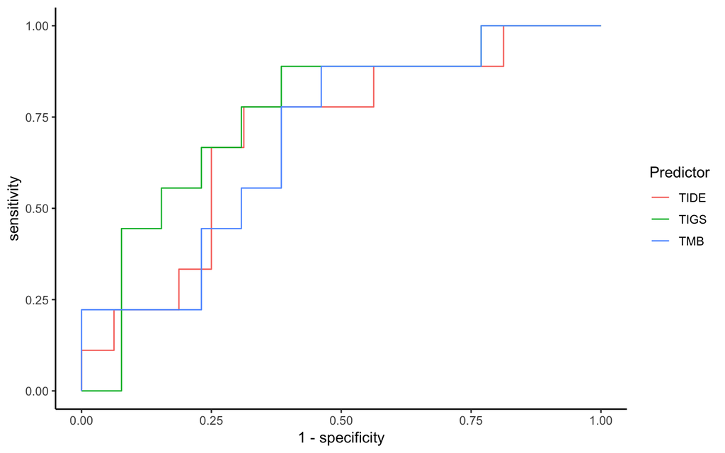

```r
#---------------------------------------
# Snyder 2017

info_Snyder = info_Snyder %>%
  dplyr::left_join(dplyr::filter(GEBiomarker, study=="Snyder2017") %>%
                      dplyr::select(-study), by=c("patient_id" = "sample")) %>%
  dplyr::left_join(TIDE_Snyder %>% dplyr::select(Patient, TIDE), by = c("patient_id" = "Patient"))

Snyder2017_roc_TMB = roc(info_Snyder$is_benefit, info_Snyder$nTMB)
Snyder2017_roc_APS = roc(info_Snyder$is_benefit, info_Snyder$APS)
Snyder2017_roc_TIGS = roc(info_Snyder$is_benefit, info_Snyder$TIGS)
Snyder2017_roc_IIS = roc(info_Snyder$is_benefit, info_Snyder$IIS)
Snyder2017_roc_CD8 = roc(info_Snyder$is_benefit, info_Snyder$CD8)
Snyder2017_roc_PDL1 = roc(info_Snyder$is_benefit, info_Snyder$PDL1)
Snyder2017_roc_IFNG = roc(info_Snyder$is_benefit, info_Snyder$IFNG)
Snyder2017_roc_TIDE = roc(info_Snyder$is_benefit, info_Snyder$TIDE)



ggroc(list(TMB=Snyder2017_roc_TMB, TIGS=Snyder2017_roc_TIGS, TIDE=Snyder2017_roc_TIDE),
      legacy.axes = TRUE) +
    labs(color = "Predictor") + ggpubr::theme_classic2(base_size = 12, base_family = "Arial")
```

```r
# AUC of predictors
auc(Snyder2017_roc_TMB)   # AUC of TMB
```

```
#> Area under the curve: 0.6923
```

```r
auc(Snyder2017_roc_APS)   # AUC of APS
```

```
#> Area under the curve: 0.6806
```

```r
auc(Snyder2017_roc_TIGS)  # AUC of TIGS
```

```
#> Area under the curve: 0.7607
```

```r
auc(Snyder2017_roc_IIS)   # AUC of IIS
```

```
#> Area under the curve: 0.4792
```

```r
auc(Snyder2017_roc_CD8)   # AUC of CD8
```

```
#> Area under the curve: 0.6736
```

```r
auc(Snyder2017_roc_PDL1)  # AUC of PDL1
```

```
#> Area under the curve: 0.5833
```

```r
auc(Snyder2017_roc_IFNG)  # AUC of IFNG
```

```
#> Area under the curve: 0.6042
```

```r
auc(Snyder2017_roc_TIDE)  # AUC of TIDE
```

```
#> Area under the curve: 0.7014
```

From comparison of AUC value above, we can conclude that:

- TIGS and TIDE are better than TMB
- TIGS and TIDE have almost same performance in two melanoma datasets, however, performance of TIDE go down a little in urothelial cancer dataset, maybe resulting from the fact that TIDE is trained on data of melanoma and NSCLC cancer (this point is stated at [TIDE website](http://tide.dfci.harvard.edu/), cancer type except for melanoma and NSCLC may not work).
- APS, TMB are also not bad predictors (they have almost same performance)
- Other predictors are not good predictors, they perform differently in different datasets.

Next, we summary results above for final visualization.

```r
auc_df = tibble(
  Group = c("Hugo2016", "VanAllen2015", "Snyder2017"),
  TIGS = c(as.numeric(auc(hugo2016_roc_TIGS)),
           as.numeric(auc(VanAllen2015_roc_TIGS)),
           as.numeric(auc(Snyder2017_roc_TIGS))),
  TIDE = c(as.numeric(auc(hugo2016_roc_TIDE)),
           as.numeric(auc(VanAllen2015_roc_TIDE)),
           as.numeric(auc(Snyder2017_roc_TIDE))),
  TMB = c(as.numeric(auc(hugo2016_roc_TMB)),
          as.numeric(auc(VanAllen2015_roc_TMB)),
          as.numeric(auc(Snyder2017_roc_TMB))),
  APS = c(as.numeric(auc(hugo2016_roc_APS)),
          as.numeric(auc(VanAllen2015_roc_APS)),
          as.numeric(auc(Snyder2017_roc_APS))),
  IIS = c(as.numeric(auc(hugo2016_roc_IIS)),
          as.numeric(auc(VanAllen2015_roc_IIS)),
          as.numeric(auc(Snyder2017_roc_IIS))),
  IFNG = c(as.numeric(auc(hugo2016_roc_IFNG)),
           as.numeric(auc(VanAllen2015_roc_IFNG)),
           as.numeric(auc(Snyder2017_roc_IFNG))),
  PDL1 = c(as.numeric(auc(hugo2016_roc_PDL1)),
           as.numeric(auc(VanAllen2015_roc_PDL1)),
           as.numeric(auc(Snyder2017_roc_PDL1))),
  CD8 = c(as.numeric(auc(hugo2016_roc_CD8)),
          as.numeric(auc(VanAllen2015_roc_CD8)),
          as.numeric(auc(Snyder2017_roc_CD8)))
)

# Show AUC table
DT::datatable(auc_df,
              options = list(scrollX = TRUE, keys = TRUE), rownames = FALSE,
              caption = "AUC of biomarkers for response prediction in three ICB datasets")
```

| Group | TIGS | TIDE | TMB | APS | IIS | IFNG | PDL1 | CD8 |
| --- | --- | --- | --- | --- | --- | --- | --- | --- |
| Hugo2016 | 0.769230769230769 | 0.782967032967033 | 0.599439775910364 | 0.697802197802198 | 0.615384615384615 | 0.494505494505495 | 0.428571428571429 | 0.505494505494505 |
| VanAllen2015 | 0.755244755244755 | 0.743788819875776 | 0.67478437341451 | 0.68944099378882 | 0.670807453416149 | 0.670807453416149 | 0.608695652173913 | 0.661490683229814 |
| Snyder2017 | 0.760683760683761 | 0.701388888888889 | 0.692307692307692 | 0.680555555555556 | 0.479166666666667 | 0.604166666666667 | 0.583333333333333 | 0.673611111111111 |

### Survival comparison

```r
library(survival)
library(survminer)

#----------------------
# Cell 2016
cell2016_os = read_csv("data/cell2016_OS.csv", col_types = cols())
cell2016 = full_join(cell2016, cell2016_os, by="PatientID")

coxph(Surv(OverallSurvival, VitalStatus == "Dead") ~ nTMB, data = cell2016)
coxph(Surv(OverallSurvival, VitalStatus == "Dead") ~ TIGS, data = cell2016)
coxph(Surv(OverallSurvival, VitalStatus == "Dead") ~ APM, data = cell2016)

cell2016 %>% mutate(
    TMB_Status = ifelse(nTMB>median(nTMB), "High", "Low"),
    TIGS_Status = ifelse(TIGS>median(TIGS, na.rm = TRUE), "High",
                         ifelse(is.na(TIGS), NA, "Low"))) -> cell2016

fit1 = survfit(Surv(OverallSurvival, VitalStatus == "Dead") ~ TMB_Status, data = cell2016)
ggsurvplot(fit1, data = cell2016, pval = TRUE, fun = "pct",
           xlab = "Time (in days)")

fit2 = survfit(Surv(OverallSurvival, VitalStatus == "Dead") ~ TIGS_Status, data = cell2016)
ggsurvplot(fit2, data = cell2016, pval = TRUE, fun="pct", xlab = "Time (in days)")


# science 2015
science2015 %>% mutate(TIGS = log(nTMB) * APM,
                    TMB_Status = ifelse(nTMB>median(nTMB, na.rm = TRUE), "High",
                                        ifelse(is.na(nTMB), NA, "Low")),
                    TIGS_Status = ifelse(TIGS>median(TIGS, na.rm = TRUE), "High",
                                         ifelse(is.na(TIGS), NA, "Low")))  %>%
    filter(group != "long-survival") -> science2015

fit1 = survfit(Surv(overall_survival, dead== 1) ~ TMB_Status, data = science2015)
ggsurvplot(fit1, data = science2015, pval = TRUE, fun="pct", xlab = "Time (in days)")

fit2 = survfit(Surv(overall_survival, dead== 1) ~ TIGS_Status, data = science2015)
ggsurvplot(fit2, data = science2015, pval = TRUE, fun="pct", xlab = "Time (in days)")

#--- plos medicine 2017
urothelial2017 %>% mutate(TMB_Status = ifelse(nTMB>median(nTMB, na.rm = TRUE), "High",
                                           ifelse(is.na(nTMB), NA, "Low")),
                       TIGS_Status = ifelse(TIGS>median(TIGS, na.rm = TRUE), "High",
                                            ifelse(is.na(TIGS), NA, "Low")))  -> urothelial2017

fit1 = survfit(Surv(os, event) ~ TMB_Status, data = urothelial2017)
ggsurvplot(fit1, data = urothelial2017, pval = TRUE, fun="pct", xlab = "Time (in days)")

fit2 = survfit(Surv(os, event) ~ TIGS_Status, data = urothelial2017)
ggsurvplot(fit2, data = urothelial2017, pval = TRUE, fun="pct", xlab = "Time (in days)")
```

### Visualization of comparison profile

Shixiang Wang

2018-12-05